```python
%%javascript
IPython.OutputArea.prototype._should_scroll = function(lines) {
    return false;
}
```

```python
# to load images for this tutorial
from IPython.display import Image
import os
path = os.getcwd()
```

# Post Overview.

1. A Primer on Hypothesis Testing.
2. Types of Errors .
3. Type 1 Error.
4. Type 2 Error.
5. Relationship between \(\alpha \) and \(\beta \).

# A Primer on Hypothesis Testing.

**Hypothesis Testing (test of significance):**

- A hypothesis is a proposed explanation for a phenomenon that is based on observations
- A hypothesis test is a formal process used to explain a phenomenon by comparing observed data with a claim.
- In statistical hypothesis testing, two claims are compared. These claims are referred to as the **Null Hypothesis** and **Alternative Hypothesis**.
- The **Null Hypothesis** is a statement that there is no relation between the phenomenon under investigation.
- The **Alternative Hypothesis** is a statement that provides an alternative to the null hypothesis, and states that there is some kind of relation.
- The results of a significance test are expressed in terms of probability. The probability measures how well the data and the claim agree.
- Statistical hypothesis testing uses probabilities in making decisions or arriving at a conclusion.

**Sampling Limitation in Hypothesis Testing.**

- In most cases, researchers do not have access to measure the entire population, and must rely on a sample to make inferences about the properties of the population as a whole.
- Statisticians have developed various test statistics (models) that use sampled data to aid in hypothesis testing.
- Since statistical inferences are based on a sampling of the population, it may occasionally misrepresent the population enough to cause errors in the hypothesis test.
- These errors can result in misinterpretation of the results.
- The aim of this post is to discuss the types of errors in hypothesis testing, their causes, and how to manage them.

# Types of Errors

**Probabilities in Hypothesis Testing**

**Error Types**

- Statistical hypothesis testing is based on sampling data from a larger population.
- Sampling introduces random errors in our system and results in some level of uncertainty.
- Even with a statistically significant result with a **p-value** is less than \(\alpha\) does not imply 100% certainty.
- A **p-value** is a probability and there is always some chance of making an incorrect conclusion regarding accepting or rejecting a Null hypothesis.
- There are two common mistakes that result in hypothesis testing

  **Error Types**
  - Rejecting the Null Hypothesis when the Null Hypothesis was actually true.
  - Accept a Null Hypothesis when it is actually false.
- As illustrated in this graphic below, there are two errors, referred to as either type 1 or type 2.
- The error occurs because the decision made from the statistical analysis do not align with the actual state.
- The chances of committing these errors are inversely proportional. Decreasing one type error rate increases the other type error rate and vice versa.
- The following sections will discuss each error type in more detail.

[figure not shown]

.

# Type 1 Error.

**The \(\alpha\) error: when you Reject Null when Null is true!**

- Is known as a false positive error
- A false positive error is an error that occurs when the Null Hypothesis \(H_{0} \) is true but you reject the Null Hypothesis \(H_{0} \)
- In practical terms, this error means you reported a significant result when in fact they occured by chance and are not really significant.
- The probability of making a type 1 error is represented by the level of significance \(\alpha \). which is the p-value below which you decide to reject the null hypothesis.
- In other words, an \(\alpha \) of 0.05 indicates that you are willing to accept a 5% chance of being wrong if you reject the null hypothesis when in fact it is true.
- You can reduce the risk of a type 1 error by lowering the \(\alpha \), such as using 0.01, which mean there is a 1% chance of making a type 1 error.
- Recall that type 1 and type 2 errors are inversely proportional, so if you lower the \(\alpha \) level, you also increase the risk of the type 2 error \(\beta \). Beta \(\beta \) will be discussed in the next section.
- A fundamental problem with making type 1 errors is making changes or setting interventions when they are unnecessary.

# Type II Error.

**The \(\beta\) error: when you Accept Null when Null is false!**

- Is known as the false negative error.
- A false negative error is an error that occurs when the Null Hypothesis \(H_{0} \) is false but you accept the Null Hypothesis (H_{0} \).
- In practical terms, the researcher concluded there is not a significant effect, when in actuality there is a significant result.
- In other words: there is evidence to reject the null hypothesis but you do not reject the null hypothesis.
- The probability of making a type 2 error is called Beta \(\beta\).
- This is related to the power of the statistical test, called **power**.
- Power = 1 - \(\beta \).
- You can decrease the risk of committing a type 2 error by increasing your power, and this is often done by increasing the sample size.
- Increasing the sample size can help detect a difference if one truly exists.
- A fundamental problem with making type 2 errors is preserving the status quo when change is needed.

# Relationship between \(\alpha \) and \(\beta \) Error Types

**Whats the deal with \(\alpha \) and \(\beta \)?**

```python
# scientific calculations
import numpy as np

# Import Statistics library
import scipy.stats

# Data visualization
import matplotlib.pyplot as plt
plt.style.use('seaborn')
import seaborn as sns
%matplotlib inline

# seed the random number generator so you get the same results
np.random.seed(10)

#Mean weight and sd for the distribution where the sample will be generated
gr1_mean = 190
gr1_sd = 7.2

# Generate a normal distribution for gr1 weights
gr1_weight = scipy.stats.norm(gr1_mean, gr1_sd)

#Mean weight and sd for gr2s: True mean and std
gr2_mean = 163
gr2_sd = 7.2

# Generate a normal distribution for gr2 weights
gr2_weight = scipy.stats.norm(gr2_mean, gr2_sd)

# to plot the PDFs
def evaluate_PDF(rv, x=4):
    '''Input: a random variable object, standard deviation
       output : x and y values for the normal distribution
       '''

    # Identify the mean and standard deviation of random variable
    mean = rv.mean()
    std = rv.std()

    # Use numpy to calculate evenly spaced numbers over the specified interval (4 sd) and generate 100 samples.
    xs = np.linspace(mean - x*std, mean + x*std, 100)

    # Calculate the peak of normal distribution i.e. probability density.
    ys = rv.pdf(xs)

    return xs, ys # Return calculated values
```

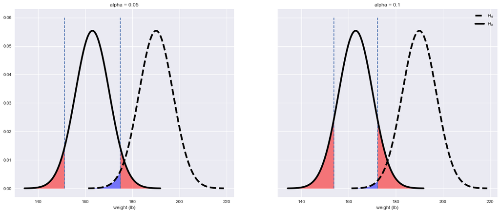

```python
fig, axes = plt.subplots(1,2, figsize =(20,8), sharey=True)

for alpha in [0.05,0.1]:
    idx = int(alpha/0.05)-1

    #alternative hypothesis plot
    gr1_xs, gr1_ys = evaluate_PDF(gr1_weight)
    axes[idx].plot(gr1_xs, gr1_ys, label='Alternative H', linewidth=4, color='black', linestyle="dashed")

    #null hypothesis plot
    gr2_xs, gr2_ys = evaluate_PDF(gr2_weight)
    axes[idx].plot(gr2_xs, gr2_ys, label='Null H', linewidth=4, color='black')

    #critical values
    thresh_l = gr2_weight.ppf(alpha)
    thresh_r = gr2_weight.ppf(1-alpha)

    axes[idx].vlines(thresh_r,ymin=0,ymax=0.06, linestyles ='dashed')
    axes[idx].vlines(thresh_l,ymin=0,ymax=0.06, linestyles ='dashed')

    axes[idx].fill_betweenx(gr1_ys,x1=thresh_r,x2 = gr1_xs, where = gr1_xs < thresh_r, color='b', alpha=0.5)
    axes[idx].fill_betweenx(gr2_ys,x1=gr2_xs,x2=thresh_r, where = gr2_xs > thresh_r,color='r', alpha=0.5)
    axes[idx].fill_betweenx(gr2_ys,x1=gr2_xs,x2=thresh_l, where = gr2_xs < thresh_l,color='r', alpha=0.5)

    axes[idx].set_xlabel('weight (lb)')
    axes[idx].set_title(f'alpha = {alpha}')
    plt.legend([r"$H_{A}$", r"$H_{0}$"])
```